# Comparing CONUS + Global Products

2026-06-29

# Purpose

`GROWdb` is the **CONUS-only** product. It was built largely from U.S.-specific source layers, including NHDPlus V2, StreamCat, and USGS gage data. The **global master table** (`site_global_master_table.csv`) re-derives an analogous set of descriptors for the same sampling sites using global source layers, including HydroSHEDS / HydroBASINS / HydroRIVERS / HydroATLAS, WorldClim 2.1, global land cover, SoilGrids-style soils, and related global products.

Because the two products draw on different underlying datasets, identical numbers are not expected everywhere. The goal here is narrower: for variables that represent the same physical concept, check whether the global workflow lands in the same general place as the established CONUS workflow.

This version assumes the global post-processing workflow has already added annual climate summaries to `site_global_master_table`, including:

- `tminSite_annual_mean_c`, `tmaxSite_annual_mean_c`, `tmeanSite_annual_mean_c`, `precipSite_annual_sum_mm`
- `tminWs_annual_mean_c`, `tmaxWs_annual_mean_c`, `tmeanWs_annual_mean_c`, `precipWs_annual_sum_mm`

NPP is intentionally excluded because it is no longer part of the global workflow.

# Load and join

```r
raw <- read_csv("data/date_lat_long_grow_KKA_05.05.26.csv", show_col_types = FALSE)
grow <- read_csv("data/0-shared/GROWdb_20260528.csv", show_col_types = FALSE)
global <- read_csv("data/global_watershed_geospatial/extracted/site_global_master_table.csv", show_col_types = FALSE)

cat("Master table:", nrow(raw), "rows x", ncol(raw), "cols\n")
```

```
## Master table: 527 rows x 4 cols
```

```r
cat("Global table:", nrow(global), "rows x", ncol(global), "cols\n")
```

```
## Global table: 527 rows x 176 cols
```

```r
cat("CONUS table:", nrow(grow), "rows x", ncol(grow), "cols\n")
```

```
## CONUS table: 549 rows x 328 cols
```

The two tables share a sample identifier: `sample_name` in the global table and `SampleName` in GROWdb. We join on that identifier rather than coordinates, because the two products may carry slightly different coordinate precision.

```r
global <- global %>%
  rename(sample_id = sample_name)

grow <- grow %>%
  rename(sample_id = SampleName)

j <- inner_join(global, grow, by = "sample_id", suffix = c("_global", "_grow"))

n_global_only <- length(setdiff(global$sample_id, grow$sample_id))
n_grow_only <- length(setdiff(grow$sample_id, global$sample_id))

cat("Matched site-pairs:", nrow(j), "\n")
```

```
## Matched site-pairs: 527
```

```r
cat("In global only:", n_global_only, "\n")
```

```
## In global only: 0
```

```r
cat("In GROWdb only:", n_grow_only, "\n")
```

```
## In GROWdb only: 22
```

# Helper functions

These helpers make the analysis robust to post-join suffixes. If a field exists in both input tables, it is usually renamed to `_global` and `_grow`. If it exists in only one table, it usually remains unsuffixed. The helpers below check all plausible candidate names and report the actual column used.

```r
first_present <- function(data, candidates) {
  candidates <- unlist(candidates, use.names = FALSE)
  hits <- candidates[candidates %in% names(data)]
  if (length(hits) == 0) NA_character_ else hits[1]
}

as_numeric_vector <- function(x, n_expected = NULL) {
  # readr/dplyr joins should produce atomic vectors, but this keeps the workflow
  # from breaking if a previous step accidentally created a one-value list column.
  if (is.data.frame(x)) {
    x <- x[[1]]
  }

  if (is.list(x) && !is.data.frame(x)) {
    x <- purrr::map_dbl(x, function(z) {
      if (length(z) == 0 || all(is.na(z))) {
        NA_real_
      } else {
        suppressWarnings(as.numeric(z[[1]]))
      }
    })
  }

  x <- suppressWarnings(as.numeric(x))

  if (!is.null(n_expected) && length(x) != n_expected) {
    out <- rep(NA_real_, n_expected)
    n_copy <- min(length(x), n_expected)
    out[seq_len(n_copy)] <- x[seq_len(n_copy)]
    x <- out
  }

  x
}

pick_numeric <- function(data, candidates, transform = identity) {
  candidates <- unlist(candidates, use.names = FALSE)
  hits <- candidates[candidates %in% names(data)]

  if (length(hits) == 0) {
    return(rep(NA_real_, nrow(data)))
  }

  transform <- purrr::as_mapper(transform)

  vals <- purrr::map(hits, ~ as_numeric_vector(data[[.x]], n_expected = nrow(data)))
  n_finite <- purrr::map_int(vals, ~ sum(is.finite(.x)))

  best_i <- if (any(n_finite > 0)) {
    which(n_finite > 0)[1]
  } else {
    1
  }

  as_numeric_vector(transform(vals[[best_i]]), n_expected = nrow(data))
}

row_sum_candidates <- function(data, candidates) {
  hits <- candidates[candidates %in% names(data)]

  if (length(hits) == 0) {
    return(rep(NA_real_, nrow(data)))
  }

  mat <- data %>%
    dplyr::select(dplyr::all_of(hits)) %>%
    dplyr::mutate(dplyr::across(dplyr::everything(), ~ suppressWarnings(as.numeric(.x)))) %>%
    as.data.frame()

  out <- rowSums(mat, na.rm = TRUE)
  all_missing <- rowSums(!is.na(mat)) == 0
  out[all_missing] <- NA_real_
  out
}

count_non_na <- function(data, candidates) {
  hits <- candidates[candidates %in% names(data)]

  if (length(hits) == 0) {
    return(tibble(
      present = FALSE,
      column_used = NA_character_,
      n_nonNA = NA_integer_
    ))
  }

  counts <- purrr::map_int(hits, ~ sum(!is.na(data[[.x]])))

  best_i <- if (any(counts > 0)) {
    which(counts > 0)[1]
  } else {
    1
  }

  tibble(
    present = TRUE,
    column_used = hits[best_i],
    n_nonNA = counts[best_i]
  )
}

empty_stats <- function(n = 0L) {
  tibble(
    n = as.integer(n),
    pearson_r = NA_real_,
    spearman_rho = NA_real_,
    bias_grow_minus_global = NA_real_,
    rmse = NA_real_,
    global_median = NA_real_,
    grow_median = NA_real_
  )
}

safe_cor <- function(x, y, method) {
  if (length(x) < 3 || stats::sd(x) == 0 || stats::sd(y) == 0) {
    return(NA_real_)
  }
  suppressWarnings(stats::cor(x, y, method = method))
}

compare_pair <- function(data, x_col, y_col) {
  if (!x_col %in% names(data) || !y_col %in% names(data)) {
    return(empty_stats(0L))
  }

  x <- as_numeric_vector(data[[x_col]], n_expected = nrow(data))
  y <- as_numeric_vector(data[[y_col]], n_expected = nrow(data))
  ok <- is.finite(x) & is.finite(y)
  x <- x[ok]
  y <- y[ok]
  n <- length(x)

  if (n == 0) {
    return(empty_stats(0L))
  }

  tibble(
    n = as.integer(n),
    pearson_r = safe_cor(x, y, method = "pearson"),
    spearman_rho = safe_cor(x, y, method = "spearman"),
    bias_grow_minus_global = mean(y - x),
    rmse = sqrt(mean((y - x)^2)),
    global_median = median(x),
    grow_median = median(y)
  )
}

run_specs <- function(data, specs) {
  required_cols <- c("concept", "category", "x_col", "y_col", "unit", "note")
  missing_cols <- setdiff(required_cols, names(specs))

  if (length(missing_cols) > 0) {
    stop("Specs table is missing required columns: ", paste(missing_cols, collapse = ", "))
  }

  specs %>%
    dplyr::mutate(
      x_present = x_col %in% names(data),
      y_present = y_col %in% names(data),
      stats = purrr::map2(x_col, y_col, ~ compare_pair(data, .x, .y))
    ) %>%
    tidyr::unnest(cols = c(stats)) %>%
    dplyr::select(
      category, concept, unit, n, pearson_r, spearman_rho,
      bias_grow_minus_global, rmse, global_median, grow_median,
      x_col, y_col, x_present, y_present, note
    )
}

make_pairs <- function(data, specs) {
  purrr::pmap_dfr(
    specs,
    function(concept, category, x_col, y_col, unit, note, ...) {
      if (!x_col %in% names(data) || !y_col %in% names(data)) {
        return(tibble())
      }

      tibble(
        concept = concept,
        category = category,
        unit = unit,
        global = as_numeric_vector(data[[x_col]], n_expected = nrow(data)),
        grow = as_numeric_vector(data[[y_col]], n_expected = nrow(data))
      )
    }
  ) %>%
    dplyr::filter(is.finite(global), is.finite(grow))
}
```

# Build analysis columns

This step creates stable analysis columns with explicit names. The rest of the Rmd uses only these stable names, so the comparison does not break if the join creates `_global` / `_grow` suffixes differently than expected.

```r
j <- j %>%
  mutate(
    # Global-side aliases ---------------------------------------------------
    global_aridity_ws = pick_numeric(., c("AridityWs_global", "AridityWs")),
    global_aridity_site = pick_numeric(., c("AriditySite_global", "AriditySite")),
    global_area_km2 = pick_numeric(., c("AreaSqKmWs_global", "AreaSqKmWs", "WsAreaSqKm_global", "WsAreaSqKm")),
    global_stream_order = pick_numeric(., c("StreamOrder_global", "StreamOrder")),
    global_discharge_cms = pick_numeric(., c("DischargeCMS_global", "DischargeCMS")),
    global_elevation_site_m = pick_numeric(., c("ElevationSite_global", "ElevationSite")),

    global_precip_site_mm = pick_numeric(., c("precipSite_annual_sum_mm_global", "precipSite_annual_sum_mm")),
    global_tmean_site_c = pick_numeric(., c("tmeanSite_annual_mean_c_global", "tmeanSite_annual_mean_c")),
    global_tmax_site_c = pick_numeric(., c("tmaxSite_annual_mean_c_global", "tmaxSite_annual_mean_c")),
    global_tmin_site_c = pick_numeric(., c("tminSite_annual_mean_c_global", "tminSite_annual_mean_c")),

    global_precip_ws_mm = pick_numeric(., c("precipWs_annual_sum_mm_global", "precipWs_annual_sum_mm")),
    global_tmean_ws_c = pick_numeric(., c("tmeanWs_annual_mean_c_global", "tmeanWs_annual_mean_c")),
    global_tmax_ws_c = pick_numeric(., c("tmaxWs_annual_mean_c_global", "tmaxWs_annual_mean_c")),
    global_tmin_ws_c = pick_numeric(., c("tminWs_annual_mean_c_global", "tminWs_annual_mean_c")),

    global_clay_ws = pick_numeric(., c("ClayWs_global", "ClayWs")),
    global_sand_ws = pick_numeric(., c("SandWs_global", "SandWs")),
    global_dam_dens_ws = pick_numeric(., c("DamDensWs_global", "DamDensWs")),

    # GROWdb-side aliases ---------------------------------------------------
    grow_aridity_ws = pick_numeric(., c("AridityWs_grow", "AridityWs")),
    grow_aridity_site = pick_numeric(., c("AriditySite_grow", "AriditySite")),
    grow_area_km2 = pick_numeric(., c("AreaSqKmWs_grow", "WsAreaSqKm_grow", "totdasqkm", "AreaSqKmWs", "WsAreaSqKm")),
    grow_stream_order = pick_numeric(., c("streamorde_grow", "streamorde")),
    grow_qe_ma_cms = pick_numeric(., c("qe_ma_grow", "qe_ma"), transform = ~ .x * 0.0283168),
    grow_cfs_cms = pick_numeric(., c("CFS_grow", "CFS"), transform = ~ .x * 0.0283168),
    grow_minelev_m = pick_numeric(., c("minelevsmo_grow", "minelevsmo"), transform = ~ .x / 100),

    grow_precip_site_mm = pick_numeric(., c("PrecipSite_grow", "PrecipSite")),
    grow_tmean_site_c = pick_numeric(., c("TmeanSite_grow", "TmeanSite")),
    grow_tmax_site_c = pick_numeric(., c("TmaxSite_grow", "TmaxSite")),
    grow_tmin_site_c = pick_numeric(., c("TminSite_grow", "TminSite")),

    grow_precip_ws_mm = pick_numeric(., c("PrecipWs_grow", "PrecipWs")),
    grow_tmean_ws_c = pick_numeric(., c("TmeanWs_grow", "TmeanWs")),
    grow_tmax_ws_c = pick_numeric(., c("TmaxWs_grow", "TmaxWs")),
    grow_tmin_ws_c = pick_numeric(., c("TminWs_grow", "TminWs")),

    grow_clay_ws = pick_numeric(., c("ClayWs_grow", "ClayWs")),
    grow_sand_ws = pick_numeric(., c("SandWs_grow", "SandWs")),
    grow_dam_dens_ws = pick_numeric(., c("DamDensWs_grow", "DamDensWs"))
  )
```

Resolved columns used for selected analysis fields.

| analysis_field | column_used | present | n_nonNA |
| --- | --- | --- | --- |
| global_area_km2 | NA | FALSE | NA |
| grow_area_km2 | NA | FALSE | NA |
| global_precip_ws_mm | NA | FALSE | NA |
| grow_precip_ws_mm | NA | FALSE | NA |
| global_tmean_ws_c | NA | FALSE | NA |
| grow_tmean_ws_c | NA | FALSE | NA |
| global_tmax_ws_c | NA | FALSE | NA |
| grow_tmax_ws_c | NA | FALSE | NA |
| global_tmin_ws_c | NA | FALSE | NA |
| grow_tmin_ws_c | NA | FALSE | NA |

# Missing value summary for the global table

```r
na_summary_global <- global %>%
  summarise(across(everything(), ~ sum(is.na(.x)))) %>%
  pivot_longer(
    everything(),
    names_to = "column",
    values_to = "n_na"
  ) %>%
  filter(n_na > 0) %>%
  arrange(desc(n_na))

nice_table(na_summary_global, caption = "Remaining missing values in the global master table.")
```

Remaining missing values in the global master table.

| column | n_na |
| --- | --- |
| notes | 446 |
| HYRIV_ID | 49 |
| DischargeCMS | 49 |
| MainRiv | 49 |
| HYBAS_ID | 3 |
| PFAF_ID | 3 |
| pfaf_2 | 3 |
| pfaf_4 | 3 |
| pfaf_6 | 3 |
| pfaf_8 | 3 |
| pfaf_10 | 3 |
| SUB_AREA | 3 |
| UP_AREA | 3 |

# Positive controls: shared-source variables

Aridity is kept as the main positive control. NPP is excluded because it is no longer used in this workflow.

```r
control_specs <- tribble(
  ~concept, ~category, ~x_col, ~y_col, ~unit, ~note,
  "Aridity (watershed)", "Control", "global_aridity_ws", "grow_aridity_ws", "index", "Shared-source or directly comparable aridity field",
  "Aridity (site)", "Control", "global_aridity_site", "grow_aridity_site", "index", "Shared-source or directly comparable aridity field"
)

control_res <- run_specs(j, control_specs)

nice_table(
  control_res %>% dplyr::select(-category, -x_col, -y_col, -x_present, -y_present),
  caption = "Positive controls. Expect near-identical results if the join and units are correct."
)
```

Positive controls. Expect near-identical results if the join and units are correct.

| concept | unit | n | pearson_r | spearman_rho | bias_grow_minus_global | rmse | global_median | grow_median | note |
| --- | --- | --- | --- | --- | --- | --- | --- | --- | --- |
| Aridity (watershed) | index | 389 | 1 | 1 | 0 | 0 | 0.829 | 0.829 | Shared-source or directly comparable aridity field |
| Aridity (site) | index | 403 | 1 | 1 | 0 | 0 | 0.792 | 0.792 | Shared-source or directly comparable aridity field |

# Crosswalk of overlapping variables

Conceptual crosswalk between the two products.

| Concept | Global source | GROWdb source | Unit reconciliation |
| --- | --- | --- | --- |
| Watershed / drainage area | HydroSHEDS / HydroBASINS upstream area | NHDPlus V2 total drainage area | both km^2 |
| Stream order | HydroRIVERS Strahler | NHDPlus stream order | none |
| Mean annual discharge | HydroATLAS DischargeCMS | NHDPlus EROM qe_ma | GROW CFS -> CMS (x0.0283168) |
| Discharge at gage | HydroATLAS DischargeCMS | USGS gage CFS | GROW CFS -> CMS (x0.0283168) |
| Site elevation | DEM point elevation | NHDPlus smoothed minimum elevation | GROW cm -> m (/100) |
| Site annual precip | WorldClim 2.1 annual summary | GROWdb / StreamCat site precip | both mm/yr |
| Site annual tmean | WorldClim 2.1 annual summary | GROWdb / StreamCat site tmean | both degC |
| Site annual tmax | WorldClim 2.1 annual summary | GROWdb / StreamCat site tmax | both degC |
| Site annual tmin | WorldClim 2.1 annual summary | GROWdb / StreamCat site tmin | both degC |
| Watershed annual precip | WorldClim 2.1 watershed annual summary | GROWdb / StreamCat watershed precip | both mm/yr |
| Watershed annual tmean | WorldClim 2.1 watershed annual summary | GROWdb / StreamCat watershed tmean | both degC |
| Watershed annual tmax | WorldClim 2.1 watershed annual summary | GROWdb / StreamCat watershed tmax | both degC |
| Watershed annual tmin | WorldClim 2.1 watershed annual summary | GROWdb / StreamCat watershed tmin | both degC |
| Watershed clay | SoilGrids-style global soil | StreamCat soil | both % |
| Watershed sand | SoilGrids-style global soil | StreamCat soil | both % |
| Watershed dam density | GOODD / GRanD-style global inventories | NID / StreamCat | different inventories; divergence expected |
| Land cover | Copernicus/ESA fractions | NLCD 2016 StreamCat percentages | global fraction * 100 vs aggregated NLCD % |

```r
overlap_specs <- tribble(
  ~concept, ~category, ~x_col, ~y_col, ~unit, ~note,
  "Watershed area", "Delineation", "global_area_km2", "grow_area_km2", "km^2", "HydroSHEDS/HydroBASINS vs NHDPlus total drainage area",
  "Stream order", "Network", "global_stream_order", "grow_stream_order", "Strahler", "HydroRIVERS vs NHDPlus",
  "Discharge (modeled)", "Hydrology", "global_discharge_cms", "grow_qe_ma_cms", "m^3/s", "HydroATLAS vs NHDPlus EROM",
  "Discharge (gage)", "Hydrology", "global_discharge_cms", "grow_cfs_cms", "m^3/s", "HydroATLAS vs USGS gage",
  "Site elevation", "Terrain", "global_elevation_site_m", "grow_minelev_m", "m", "Point DEM vs NHDPlus reach elevation",

  "Site precip (annual)", "Climate", "global_precip_site_mm", "grow_precip_site_mm", "mm/yr", "WorldClim site annual precip vs GROWdb site precip",
  "Site tmean (annual)", "Climate", "global_tmean_site_c", "grow_tmean_site_c", "degC", "WorldClim site annual tmean vs GROWdb site tmean",
  "Site tmax (annual)", "Climate", "global_tmax_site_c", "grow_tmax_site_c", "degC", "WorldClim site annual tmax vs GROWdb site tmax",
  "Site tmin (annual)", "Climate", "global_tmin_site_c", "grow_tmin_site_c", "degC", "WorldClim site annual tmin vs GROWdb site tmin",

  "Watershed precip (annual)", "Climate", "global_precip_ws_mm", "grow_precip_ws_mm", "mm/yr", "WorldClim watershed annual precip vs GROWdb watershed precip",
  "Watershed tmean (annual)", "Climate", "global_tmean_ws_c", "grow_tmean_ws_c", "degC", "WorldClim watershed annual tmean vs GROWdb watershed tmean",
  "Watershed tmax (annual)", "Climate", "global_tmax_ws_c", "grow_tmax_ws_c", "degC", "WorldClim watershed annual tmax vs GROWdb watershed tmax",
  "Watershed tmin (annual)", "Climate", "global_tmin_ws_c", "grow_tmin_ws_c", "degC", "WorldClim watershed annual tmin vs GROWdb watershed tmin",

  "Watershed clay", "Soil", "global_clay_ws", "grow_clay_ws", "%", "SoilGrids vs StreamCat",
  "Watershed sand", "Soil", "global_sand_ws", "grow_sand_ws", "%", "SoilGrids vs StreamCat",
  "Watershed dam density", "Human impact", "global_dam_dens_ws", "grow_dam_dens_ws", "dams/km^2", "Different dam inventories; divergence expected"
)

overlap_res <- run_specs(j, overlap_specs)

overlap_skipped <- overlap_res %>%
  dplyr::filter(n == 0 | !x_present | !y_present) %>%
  dplyr::select(concept, x_col, y_col, x_present, y_present, n, note)

nice_table(
  overlap_res %>%
    dplyr::select(-category, -x_col, -y_col, -x_present, -y_present),
  caption = "Concordance of overlapping variables."
)
```

Concordance of overlapping variables.

| concept | unit | n | pearson_r | spearman_rho | bias_grow_minus_global | rmse | global_median | grow_median | note |
| --- | --- | --- | --- | --- | --- | --- | --- | --- | --- |
| Watershed area | km^2 | 389 | 1.000 | 1.000 | 0.000 | 0.000 | 1492.480 | 1492.480 | HydroSHEDS/HydroBASINS vs NHDPlus total drainage area |
| Stream order | Strahler | 372 | 0.937 | 0.935 | 0.642 | 1.056 | 5.000 | 5.000 | HydroRIVERS vs NHDPlus |
| Discharge (modeled) | m^3/s | 358 | 0.965 | 0.858 | -104.570 | 1047.418 | 48.947 | 29.442 | HydroATLAS vs NHDPlus EROM |
| Discharge (gage) | m^3/s | 248 | 0.862 | 0.888 | -188.965 | 1774.998 | 90.571 | 33.697 | HydroATLAS vs USGS gage |
| Site elevation | m | 372 | 0.995 | 0.969 | -77.003 | 127.166 | 240.000 | 159.280 | Point DEM vs NHDPlus reach elevation |
| Site precip (annual) | mm/yr | 403 | 0.970 | 0.971 | 39.169 | 120.758 | 1019.000 | 1057.140 | WorldClim site annual precip vs GROWdb site precip |
| Site tmean (annual) | degC | 403 | 0.995 | 0.984 | 0.471 | 0.728 | 10.451 | 10.730 | WorldClim site annual tmean vs GROWdb site tmean |
| Site tmax (annual) | degC | 403 | 0.992 | 0.989 | 0.347 | 0.687 | 16.659 | 16.860 | WorldClim site annual tmax vs GROWdb site tmax |
| Site tmin (annual) | degC | 403 | 0.994 | 0.981 | 0.591 | 0.915 | 4.098 | 4.580 | WorldClim site annual tmin vs GROWdb site tmin |
| Watershed precip (annual) | mm/yr | 0 | NA | NA | NA | NA | NA | NA | WorldClim watershed annual precip vs GROWdb watershed precip |
| Watershed tmean (annual) | degC | 0 | NA | NA | NA | NA | NA | NA | WorldClim watershed annual tmean vs GROWdb watershed tmean |
| Watershed tmax (annual) | degC | 0 | NA | NA | NA | NA | NA | NA | WorldClim watershed annual tmax vs GROWdb watershed tmax |
| Watershed tmin (annual) | degC | 0 | NA | NA | NA | NA | NA | NA | WorldClim watershed annual tmin vs GROWdb watershed tmin |
| Watershed clay | % | 372 | 0.888 | 0.864 | -0.530 | 4.420 | 20.446 | 20.049 | SoilGrids vs StreamCat |
| Watershed sand | % | 372 | 0.831 | 0.854 | -4.369 | 9.003 | 43.324 | 35.621 | SoilGrids vs StreamCat |
| Watershed dam density | dams/km^2 | 372 | 0.662 | 0.661 | 0.008 | 0.015 | 0.001 | 0.004 | Different dam inventories; divergence expected |

```r
if (nrow(overlap_skipped) > 0) {
  nice_table(
    overlap_skipped,
    caption = "Comparisons skipped or unresolved because one side was missing or had no paired finite values."
  )
}
```

Comparisons skipped or unresolved because one side was missing or had no paired finite values.

| concept | x_col | y_col | x_present | y_present | n | note |
| --- | --- | --- | --- | --- | --- | --- |
| Watershed precip (annual) | global_precip_ws_mm | grow_precip_ws_mm | TRUE | TRUE | 0 | WorldClim watershed annual precip vs GROWdb watershed precip |
| Watershed tmean (annual) | global_tmean_ws_c | grow_tmean_ws_c | TRUE | TRUE | 0 | WorldClim watershed annual tmean vs GROWdb watershed tmean |
| Watershed tmax (annual) | global_tmax_ws_c | grow_tmax_ws_c | TRUE | TRUE | 0 | WorldClim watershed annual tmax vs GROWdb watershed tmax |
| Watershed tmin (annual) | global_tmin_ws_c | grow_tmin_ws_c | TRUE | TRUE | 0 | WorldClim watershed annual tmin vs GROWdb watershed tmin |

# Concordance summary

```r
all_res <- bind_rows(control_res, overlap_res) %>%
  arrange(desc(pearson_r))

tiered <- all_res %>%
  mutate(agreement = case_when(
    is.na(pearson_r) ~ "no data",
    pearson_r >= 0.98 ~ "near-identical",
    pearson_r >= 0.90 ~ "strong",
    pearson_r >= 0.75 ~ "moderate",
    TRUE ~ "weak / divergent"
  )) %>%
  select(category, concept, agreement, n, pearson_r, spearman_rho,
         bias_grow_minus_global, rmse)

nice_table(tiered, caption = "All comparisons ranked by agreement tier.")
```

All comparisons ranked by agreement tier.

| category | concept | agreement | n | pearson_r | spearman_rho | bias_grow_minus_global | rmse |
| --- | --- | --- | --- | --- | --- | --- | --- |
| Control | Aridity (watershed) | near-identical | 389 | 1.000 | 1.000 | 0.000 | 0.000 |
| Delineation | Watershed area | near-identical | 389 | 1.000 | 1.000 | 0.000 | 0.000 |
| Control | Aridity (site) | near-identical | 403 | 1.000 | 1.000 | 0.000 | 0.000 |
| Terrain | Site elevation | near-identical | 372 | 0.995 | 0.969 | -77.003 | 127.166 |
| Climate | Site tmean (annual) | near-identical | 403 | 0.995 | 0.984 | 0.471 | 0.728 |
| Climate | Site tmin (annual) | near-identical | 403 | 0.994 | 0.981 | 0.591 | 0.915 |
| Climate | Site tmax (annual) | near-identical | 403 | 0.992 | 0.989 | 0.347 | 0.687 |
| Climate | Site precip (annual) | strong | 403 | 0.970 | 0.971 | 39.169 | 120.758 |
| Hydrology | Discharge (modeled) | strong | 358 | 0.965 | 0.858 | -104.570 | 1047.418 |
| Network | Stream order | strong | 372 | 0.937 | 0.935 | 0.642 | 1.056 |
| Soil | Watershed clay | moderate | 372 | 0.888 | 0.864 | -0.530 | 4.420 |
| Hydrology | Discharge (gage) | moderate | 248 | 0.862 | 0.888 | -188.965 | 1774.998 |
| Soil | Watershed sand | moderate | 372 | 0.831 | 0.854 | -4.369 | 9.003 |
| Human impact | Watershed dam density | weak / divergent | 372 | 0.662 | 0.661 | 0.008 | 0.015 |
| Climate | Watershed precip (annual) | no data | 0 | NA | NA | NA | NA |
| Climate | Watershed tmean (annual) | no data | 0 | NA | NA | NA | NA |
| Climate | Watershed tmax (annual) | no data | 0 | NA | NA | NA | NA |
| Climate | Watershed tmin (annual) | no data | 0 | NA | NA | NA | NA |

Count of variables by agreement tier.

| agreement | n |
| --- | --- |
| near-identical | 7 |
| strong | 3 |
| moderate | 3 |
| weak / divergent | 1 |

# Visual concordance

## 1:1 scatter plots

```r
pairs_long <- make_pairs(j, overlap_specs)
```

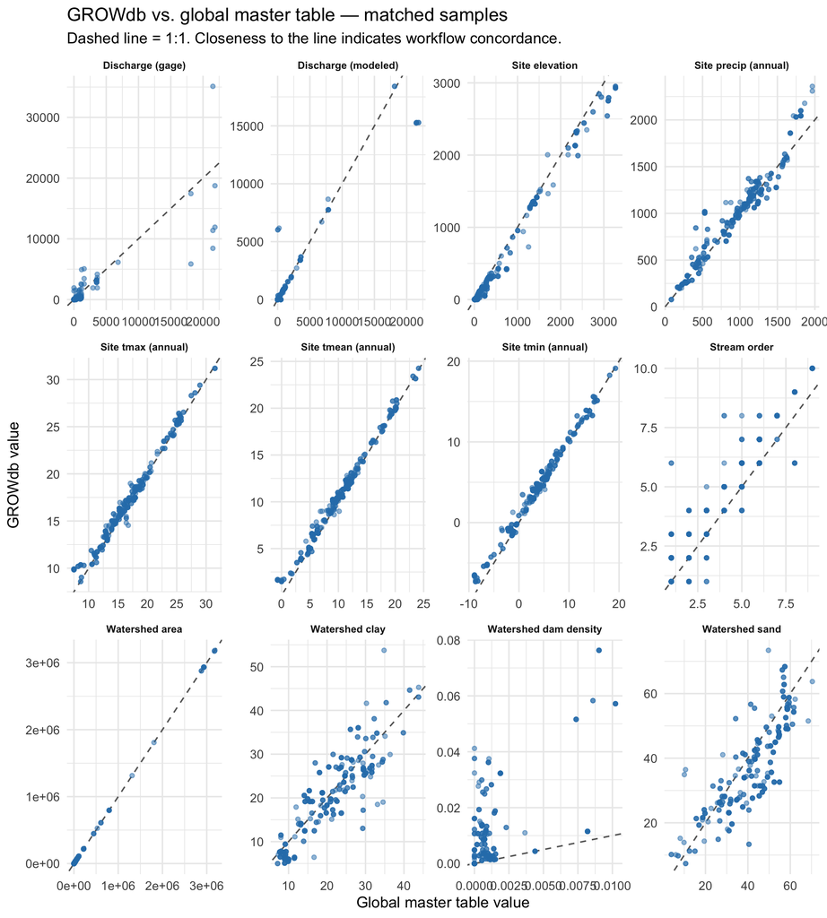

```r
ggplot(pairs_long, aes(global, grow)) +
  geom_abline(slope = 1, intercept = 0, linetype = "dashed", colour = "grey40") +
  geom_point(alpha = 0.5, size = 1.3, colour = "#2c7fb8") +
  facet_wrap(~ concept, scales = "free", ncol = 4) +
  labs(
    title = "GROWdb vs. global master table — matched samples",
    subtitle = "Dashed line = 1:1. Closeness to the line indicates workflow concordance.",
    x = "Global master table value",
    y = "GROWdb value"
  ) +
  theme(strip.text = element_text(face = "bold", size = 8))
```

## Log-log view for magnitude-spanning variables

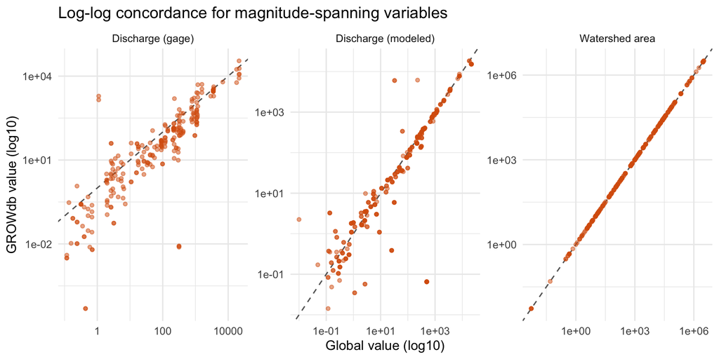

```r
log_concepts <- c("Watershed area", "Discharge (modeled)", "Discharge (gage)")

pairs_long %>%
  filter(concept %in% log_concepts, global > 0, grow > 0) %>%
  ggplot(aes(global, grow)) +
  geom_abline(slope = 1, intercept = 0, linetype = "dashed", colour = "grey40") +
  geom_point(alpha = 0.5, size = 1.3, colour = "#d95f0e") +
  scale_x_log10() +
  scale_y_log10() +
  facet_wrap(~ concept, scales = "free", ncol = 3) +
  labs(
    title = "Log-log concordance for magnitude-spanning variables",
    x = "Global value (log10)",
    y = "GROWdb value (log10)"
  )
```

## Bland-Altman plots

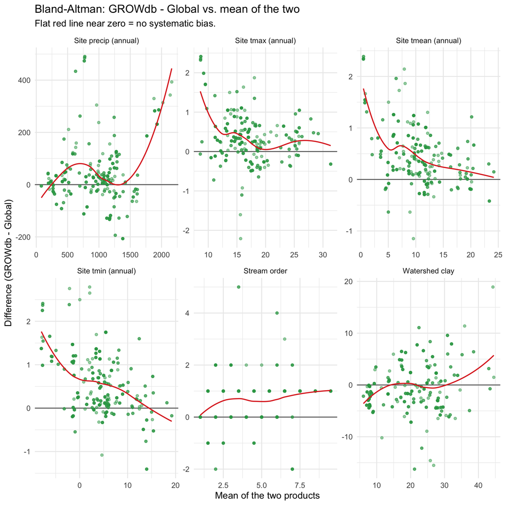

```r
ba_concepts <- c(
  "Site precip (annual)",
  "Site tmean (annual)",
  "Site tmax (annual)",
  "Site tmin (annual)",
  "Watershed precip (annual)",
  "Watershed tmean (annual)",
  "Watershed tmax (annual)",
  "Watershed tmin (annual)",
  "Watershed clay",
  "Stream order"
)

pairs_long %>%
  filter(concept %in% ba_concepts) %>%
  mutate(
    mean_val = (global + grow) / 2,
    diff_val = grow - global
  ) %>%
  ggplot(aes(mean_val, diff_val)) +
  geom_hline(yintercept = 0, colour = "grey40") +
  geom_point(alpha = 0.5, size = 1.3, colour = "#31a354") +
  geom_smooth(method = "loess", se = FALSE, colour = "#de2d26", linewidth = 0.7) +
  facet_wrap(~ concept, scales = "free", ncol = 3) +
  labs(
    title = "Bland-Altman: GROWdb - Global vs. mean of the two",
    subtitle = "Flat red line near zero = no systematic bias.",
    x = "Mean of the two products",
    y = "Difference (GROWdb - Global)"
  )
```

# Land cover: Copernicus fractions vs. NLCD classes

The global table uses continuous land-cover fractions. GROWdb uses NLCD 2016 class percentages from StreamCat. To compare them, NLCD classes are aggregated into broad groups and global fractions are converted to percentages.

```r
lc <- j %>%
  transmute(
    sample_id = sample_id,

    global_forest = 100 * pick_numeric(., c("lc_trees_mean_fraction_global", "lc_trees_mean_fraction")),
    grow_forest = row_sum_candidates(., c("PctDecid2016Ws", "PctConif2016Ws", "PctMxFst2016Ws")),

    global_crop = 100 * pick_numeric(., c("lc_cropland_mean_fraction_global", "lc_cropland_mean_fraction")),
    grow_crop = row_sum_candidates(., c("PctCrop2016Ws", "PctHay2016Ws")),

    global_grshrub = 100 * (
      pick_numeric(., c("lc_grassland_mean_fraction_global", "lc_grassland_mean_fraction")) +
        pick_numeric(., c("lc_shrubs_mean_fraction_global", "lc_shrubs_mean_fraction"))
    ),
    grow_grshrub = row_sum_candidates(., c("PctGrs2016Ws", "PctShrb2016Ws")),

    global_built = 100 * pick_numeric(., c("lc_built_mean_fraction_global", "lc_built_mean_fraction")),
    grow_built = row_sum_candidates(., c("PctUrbOp2016Ws", "PctUrbLo2016Ws", "PctUrbMd2016Ws", "PctUrbHi2016Ws")),

    global_water = 100 * pick_numeric(., c("lc_water_mean_fraction_global", "lc_water_mean_fraction")),
    grow_water = row_sum_candidates(., c("PctOw2016Ws")),

    global_wetland = 100 * pick_numeric(., c("lc_wetland_mean_fraction_global", "lc_wetland_mean_fraction")),
    grow_wetland = row_sum_candidates(., c("PctWdWet2016Ws", "PctHbWet2016Ws"))
  )

lc_specs <- tribble(
  ~concept, ~category, ~x_col, ~y_col, ~unit, ~note,
  "Forest %", "Land cover", "global_forest", "grow_forest", "%", "Copernicus trees vs NLCD forest classes",
  "Cropland %", "Land cover", "global_crop", "grow_crop", "%", "Copernicus cropland vs NLCD crop + hay",
  "Grass+shrub %", "Land cover", "global_grshrub", "grow_grshrub", "%", "Copernicus grass + shrub vs NLCD grass + shrub",
  "Developed %", "Land cover", "global_built", "grow_built", "%", "Copernicus built vs NLCD developed classes",
  "Open water %", "Land cover", "global_water", "grow_water", "%", "Copernicus water vs NLCD open water",
  "Wetland %", "Land cover", "global_wetland", "grow_wetland", "%", "Copernicus wetland vs NLCD wetland classes"
)

lc_res <- run_specs(lc, lc_specs)

nice_table(
  lc_res %>% dplyr::select(-category, -x_col, -y_col, -x_present, -y_present),
  caption = "Land cover concordance: Copernicus fractions vs aggregated NLCD 2016."
)
```

Land cover concordance: Copernicus fractions vs aggregated NLCD 2016.

| concept | unit | n | pearson_r | spearman_rho | bias_grow_minus_global | rmse | global_median | grow_median | note |
| --- | --- | --- | --- | --- | --- | --- | --- | --- | --- |
| Forest % | % | 372 | 0.936 | 0.938 | -10.889 | 15.140 | 71.586 | 55.655 | Copernicus trees vs NLCD forest classes |
| Cropland % | % | 372 | 0.933 | 0.931 | 5.562 | 9.697 | 1.142 | 4.290 | Copernicus cropland vs NLCD crop + hay |
| Grass+shrub % | % | 372 | 0.891 | 0.663 | -0.969 | 10.809 | 13.083 | 11.850 | Copernicus grass + shrub vs NLCD grass + shrub |
| Developed % | % | 372 | 0.901 | 0.825 | 4.509 | 7.625 | 0.552 | 3.370 | Copernicus built vs NLCD developed classes |
| Open water % | % | 372 | 0.970 | 0.975 | 0.097 | 0.273 | 0.552 | 0.600 | Copernicus water vs NLCD open water |
| Wetland % | % | 372 | 0.735 | 0.596 | 3.978 | 7.467 | 0.019 | 2.060 | Copernicus wetland vs NLCD wetland classes |

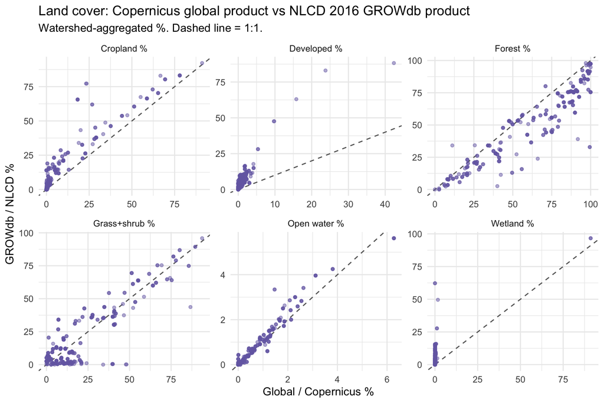

```r
lc_pairs <- make_pairs(lc, lc_specs)

ggplot(lc_pairs, aes(global, grow)) +
  geom_abline(slope = 1, intercept = 0, linetype = "dashed", colour = "grey40") +
  geom_point(alpha = 0.5, size = 1.3, colour = "#756bb1") +
  facet_wrap(~ concept, scales = "free", ncol = 3) +
  labs(
    title = "Land cover: Copernicus global product vs NLCD 2016 GROWdb product",
    subtitle = "Watershed-aggregated %. Dashed line = 1:1.",
    x = "Global / Copernicus %",
    y = "GROWdb / NLCD %"
  )
```

# Coverage gaps and non-comparable fields

Coverage of selected fields on the matched sites.

| Field checked | column_used | present | n_nonNA | status |
| --- | --- | --- | --- | --- |
| Watershed area | NA | FALSE | NA | column absent after join |
| PrecipWs | NA | FALSE | NA | column absent after join |
| TmeanWs | NA | FALSE | NA | column absent after join |
| TmaxWs | NA | FALSE | NA | column absent after join |
| TminWs | NA | FALSE | NA | column absent after join |
| CatAreaSqKm | NA | FALSE | NA | column absent after join |
| CFS | NA | FALSE | NA | column absent after join |
| gage_id | NA | FALSE | NA | column absent after join |
| Global annual watershed precip | NA | FALSE | NA | column absent after join |
| Global annual watershed tmean | NA | FALSE | NA | column absent after join |
| Global annual watershed tmax | NA | FALSE | NA | column absent after join |
| Global annual watershed tmin | NA | FALSE | NA | column absent after join |

Notes on routed-around or non-comparable fields:

- **Watershed climate is compared when populated.** The script now compares `PrecipWs`, `TmeanWs`, `TmaxWs`, and `TminWs` to the newly added global annual watershed climate summaries.
- **Column suffixes are handled explicitly.** A field may appear as `PrecipWs`, `PrecipWs_grow`, or another resolved alias depending on whether the same name also exists in the global table.
- **Ecoregion / biome are not numerically comparable.** The global table uses WWF ecoregions/biomes/realms, while GROWdb uses Omernik levels. These are different classification systems.
- **Site-level soil** in the global table has no direct GROWdb counterpart, so only watershed soil variables are compared.
- **NPP is excluded** from all summaries, tables, figures, and conclusions.

# Interpretation and conclusions

- **Controls, near-identical:** Aridity (watershed), Aridity (site).
- **Near-identical overall:** Aridity (watershed), Aridity (site), Watershed area, Site elevation, Site tmean (annual), Site tmax (annual), Site tmin (annual).
- **Strong:** Stream order, Discharge (modeled), Site precip (annual), Forest %, Cropland %, Developed %, Open water %.
- **Moderate:** Discharge (gage), Watershed clay, Watershed sand, Grass+shrub %.
- **Weak / divergent:** Watershed dam density, Wetland %.